# 3. U.S. Treasuries

## Reasons To Consider U.S. Treasuries

- High credit quality
  - As of Sept 2025, 58% of disclosed global official foreign exchange reserves is in USD-denominated assets, mostly in the Treasuries
- Tax advantages
- Highly liquid

## Types of Fixed Coupon U.S. Treasuries

$$ $$

| Type | Term Lengths | Payment Freq |
| --- | --- | --- |
| T-Bills | 4, 8, 13, 17, 26, 52 weeks | None (sold at discount and redeemed at par) |
| T-Notes | 2, 3, 5, 7, 10 years | 6M |
| T-Bonds | 20, 30 years | 6M |

$$ $$

## Example: 2-Year Treasury Note Cash Flows

- Assuming:
  - Today is Sep 2025
  - Face Value: $\$1,000$
  - Coupon Rate: $4.5\%$ annually
  - Semiannaual Coupon Payment: $$ 1000\times 0.045 /2 = \$22.5 $$

| Date | Payment |
| --- | --- |
| Mar 2026 | $22.50 |
| Sep 2026 | $22.50 |
| Mar 2027 | $22.50 |
| Sep 2027 | $1,022.50 |

## How To Buy

- You can buy on [treasurydirect.gov](https://treasurydirect.gov/) or in your brokerage account
- You can buy newly issued in an auction
- You can buy or sell in a liquid secondary market
- Auction frequency:

$$ $$

[output not shown]

$$ $$

## Bond Pricing

- Given the Treasury yield curve, the bond price is sum of all cash flows discounted by $P(t, T) = e^{-(T-t)R(t, T)}$
- Assume today is Sep 2025 and the cash flow table

| Date | Payment |
| --- | --- |
| Mar 2026 | $22.50 |
| Sep 2026 | $22.50 |
| Mar 2027 | $22.50 |
| Sep 2027 | $1,022.50 |

- Bond price is $$ 22.5 e^{-0.5\times 0.0385} + 22.5 e^{-1\times 0.0365} + 22.5 e^{-1.5\times 0.0358} + 1022.5 e^{-2\times 0.0351} = \$1018.27 $$

## Bond Pricing: Exercise I

- Recall that the discount factor $P(t, T) = e^{-(T-t)R(t, T)}$
- Consider a 2-year T-Note with face value $\$100$ and annual coupon rate $5\%$
- What's the coupon payment?
- What's the cash flow table?
- What's the bond price?

## Bond Pricing: Exercise I (Cont.)

- Semiannual coupon payment $$ 100\times 0.05 /2 = \$2.5 $$
- Cash flow table

| Date | Payment |
| --- | --- |
| Mar 2026 | $2.50 |
| Sep 2026 | $2.50 |
| Mar 2027 | $2.50 |
| Sep 2027 | $102.50 |

- Bond price $$ 2.5 e^{-0.5\times 0.0385} + 2.5 e^{-1\times 0.0365} + 2.5 e^{-1.5\times 0.0358} + 102.5 e^{-2\times 0.0351} = \$102.78 $$

## Bond Pricing: Exercise II

- Recall that the discount factor $P(t, T) = e^{-(T-t)R(t, T)}$
- Consider a 1.5-year T-Note with face value $\$100$ and annual coupon rate $4\%$
- What's the coupon payment?
- What's the cash flow table?
- What's the bond price?

## Bond Pricing: Exercise II (Cont.)

- Semiannual coupon payment $$ 100\times 0.04 /2 = \$2 $$
- Cash flow table

| Date | Payment |
| --- | --- |
| Mar 2026 | $2.00 |
| Sep 2026 | $2.00 |
| Mar 2027 | $102.00 |

- Bond price $$ 2 e^{-0.5\times 0.0385} + 2 e^{-1\times 0.0365} + 102 e^{-1.5\times 0.0358} = \$100.56 $$

## U.S. Treasury Yield Curve Construction

- The yield curve can be backed out from the bond market data
- Bond market data example for yield curve construction from Section 4.7 of Options, Futures, and Other Derivatives 11th Edition:

$$ $$

| Principal ($) | Term (years) | Annual Coupon ($) | Bond Price ($) |
| --- | --- | --- | --- |
| 100 | 0.25 | 0 | 99.6 |
| 100 | 0.50 | 0 | 99.0 |
| 100 | 1.00 | 0 | 97.8 |
| 100 | 1.50 | 4 | 102.5 |
| 100 | 2.00 | 5 | 105.0 |

$$ $$

- Our goal is to back out zero rates for each term on the table
- Be careful of the "bond yield" in the book, which is defined differently as the zero rate

## U.S. Treasury Yield Curve Construction (Cont.)

$$ $$

| Principal ($) | Term (years) | Annual Coupon ($) | Bond Price ($) |
| --- | --- | --- | --- |
| 100 | 0.25 | 0 | 99.6 |
| 100 | 0.50 | 0 | 99.0 |
| 100 | 1.00 | 0 | 97.8 |
| 100 | 1.50 | 4 | 102.5 |
| 100 | 2.00 | 5 | 105.0 |

$$ $$

- Assuming $t=0$, we can already determine the zero rate at $T=0.25$, $T=0.5$ and $T=1$, as we know the bonds have zero coupon
- Recall that $P(t, T) = e^{-(T-t)R(t, T)}$
- Solve $$ P(0, 0.25) = 99.6/100 = 0.996 = e^{-0.25 \times R(0, 0.25)} $$
- $R(0, 0.25) = 1.603\%$

## Exercise: Zero Rate for $T=0.5$ and $T=1$?

$$ $$

| Principal ($) | Term (years) | Annual Coupon ($) | Bond Price ($) |
| --- | --- | --- | --- |
| 100 | 0.25 | 0 | 99.6 |
| 100 | 0.50 | 0 | 99.0 |
| 100 | 1.00 | 0 | 97.8 |
| 100 | 1.50 | 4 | 102.5 |
| 100 | 2.00 | 5 | 105.0 |

$$ $$

- $P(t, T) = e^{-(T-t)R(t, T)}$, $t=0$
- $R(0, 0.5) = 2.01\%$
- $R(0, 1) = 2.225\%$

## What if Coupon Is Not Zero?

$$ $$

| Principal ($) | Term (years) | Annual Coupon ($) | Bond Price ($) |
| --- | --- | --- | --- |
| 100 | 1.50 | 4 | 102.5 |
| 100 | 2.00 | 5 | 105.0 |

$$ $$

- We've established that the cash flow schedule of a 1.5 year bond that pays $\$4$ annual coupon is

| $T$ | Payment |
| --- | --- |
| 0.5 | $2 |
| 1.0 | $2 |
| 1.5 | $102 |

- And we know the zero rates $R(0, 0.5) = 2.01\%$, $R(0, 1) = 2.225\%$, and the bond price $$ 2 e^{-0.5 \times R(0, 0.5)} + 2 e^{-1\times R(0, 1)} + 102 e^{-1.5\times R(0, 1.5)} = \$102.5 $$
- Thus we can back out $R(0, 1.5) = 2.284\%$

## Some Math

- Given
  - $R(0, 0.5) = 2.01\%$
  - $R(0, 1) = 2.225\%$ \begin{align*} &2 e^{-0.5 \times R(0, 0.5)} + 2 e^{-1\times R(0, 1)} + 102 e^{-1.5\times R(0, 1.5)} = 102.5 \end{align*}
- Thus \begin{align*} 102 e^{-1.5\times R(0, 1.5)} &= 102.5 - 2 e^{-0.5 \times R(0, 0.5)} + 2 e^{-1\times R(0, 1)}\\ &= 102.5 - 2 e^{-0.5 \times 0.0201} - 2 e^{-1\times 0.02225} = 98.564, \end{align*} and hence \begin{align*} R(0, 1.5) = -\frac{\log(98.564/102)}{1.5} = 0.02284 \end{align*}

## Zero Rate From Non-Zero Coupon Bond: Exercise

$$ $$

| Principal ($) | Term (years) | Annual Coupon ($) | Bond Price ($) |
| --- | --- | --- | --- |
| 100 | 2.00 | 5 | 105.0 |

- Cash flow schedule:

| $T$ | Payment |
| --- | --- |
| 0.5 | $2.5 |
| 1.0 | $2.5 |
| 1.5 | $2.5 |
| 2.0 | $102.5 |

## Dirty Price and Clean Price

- Most of the time the bond price quoted is not the price you pay to buy it!
- If you are in the middle of a coupon period, you need to pay part of the coupon too
  - What happens if such mechanism doesn't exist?
  - Why not just quote dirty price?
- The part of the coupon is called the accrued interest
- The quoted price called the clean price, and the cash price to pay is called the dirty price

$$ $$

$$ \text{Dirty price} = \text{Clean price} + \text{Accrued interest since last coupon date} $$

## Dirty Price and Clean Price (Cont.)

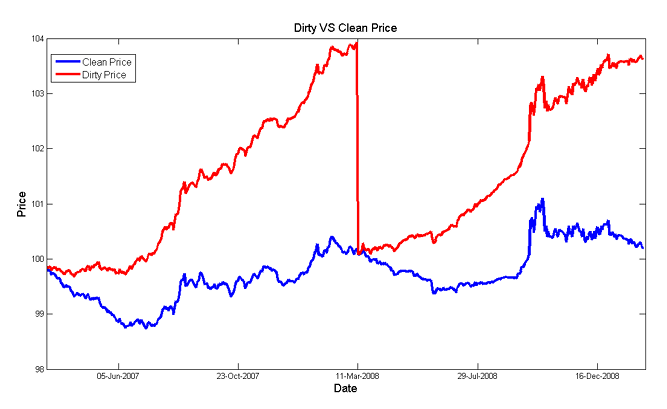

- Picture from [here](http://www.iam.fmph.uniba.sk/studium/efm/diplomovky/2010/berec/diplomovka.pdf)

## Day Count Conventions (DCCs)

- To understand how to compute the dirty price, we need to first introduce DCCs
- So far all our examples were (mistakenly) using the 30/360 DCC -- assuming there are 360 days in a year and 30 days in each month
  - Only with the 30/360 DCC, 6M has year fraction 0.5, 9M is 0.75, and 18M is 1.5
- Common DCCs are
  - Act/Act: US Treasuries, UK gilts (UK government bonds)
  - 30/360: US corporate and municipal bonds
  - Act/360: US money market instruments
  - Act/365: AUD, CAD money market instruments

## Accrued Interest -- Act/Act

- Assuming a US Treasury bond has
  - Principal $\$100$
  - Coupon payment dates 3/1 and 9/1
  - Coupon rate $8\%$
- What's the accrued interest from 3/1 to 7/3?
- The interest for the period is $\$4$
- The actual number of days between 3/1 and 7/3 is (counting the start but not the end date) $$ 31 + 30 + 31 + 30 + 2 = 124 $$
- The first for terms are for March, April, May and June, respectively
- The actual number of days between 3/1 and 9/1 is $$ 31 + 30 + 31 + 30 + 31 + 31 = 184 $$
- So the accrued interest is $$ \frac{124}{184} \times 4 = 2.6957 $$

## Accrued Interest -- 30/360

- Assuming a corporate bond in the US has the same principal, coupon payment dates and coupon rate, what's the accrued interest from 3/1 to 7/3?
- The interest for the period is $\$4$
- Number of days between 3/1 and 7/3, under the 30/360 DCC, is $$ 4\times 30 + 2 = 122 $$
- and between 3/1 and 9/1 is $$ 6\times 30 = 180 $$
- So the accrued interest is $$ \frac{122}{180} \times 4 = 2.7111 $$

## Other Treasuries

- Aside from fixed coupon Treasuries, there are also TIPS (Treasury inflation-protected securities), FRNs (Treasury floating rate notes), and Treasury STRIPS (Separate Trading of Registered Interest and Principal Securities)

$$ $$

| Type | Term Lengths | Payment Freq |
| --- | --- | --- |
| TIPS | 5, 10, 30 years | 6M |
| FRNs | 2 years | Quarterly (rate resets weekly) |
| STRIPS | Derived from notes/bonds | None (zero-coupon; sold at discount) |

$$ $$

## Treasury Inflation-Protected Securities (TIPS)

- Every 6M, the principal is adjusted with the changes in Consumer Price Index (CPI)
- Interest payment is adjusted principal multiplied by a fixed coupon rate
- At maturity, investor receives the greater of original or inflation-adjusted principal
- Coupon exempt from state and local taxes; subject to federal tax

## TIPS Example (2 Coupon Periods)

- Assuming
  - Face Value: $\$1,000$
  - Coupon Rate: $1\%$ annually ($0.5\%$ semiannually)
  - CPI:
    - First 6 months: $2\%$
    - Second 6 months: $1.5\%$
- First coupon period adjusted Principal $$ \$1,000 \times (1 + 0.02) = \$1,020 $$
- First coupon payment $$ \$1,020 \times 0.5\% = \$5.10 $$
- Second coupon period new adjusted principal $$ \$1,020 \times (1 + 0.015) = \$1,035.30 $$
- Second coupon payment $$ \$1,035.30 \times 0.5\% = \$5.18 $$

$$ $$

| Period | Adjusted Principal | Coupon Rate | Coupon Paid |
| --- | --- | --- | --- |
| First 6 months | $1,020.00 | 0.5% | $5.10 |
| Second 6 months | $1,035.30 | 0.5% | $5.18 |

## U.S. Treasury Floating Rate Notes (FRNs)

- Maturity is 2Y
- Interest resets weekly based on 13-week Treasury bill rate + fixed spread

## Treasury STRIPS

- Created by stripping interest and principal from Treasury notes/bonds
- Sold at a discount; pay full face value at maturity
- Backed by U.S. government